# Análise de dados do Youtube

Davi Toshio

May 10, 2018

```r
load('../Raw_files/all_vid_nerdologia.RData')

load('../Raw_files/html_page.RData')
load('../Raw_files/html_page_text.RData')
```

[figure not shown]

## 1.Introdução

Abordarei neste tópico uma forma de explorar informações contidas em um determinado canal do Youtube. Como exemplo, estarei demonstrando a obtenção e análise dos dados proveniente do canal “Nerdologia”, dos autores Atila Iamarino e Filipe Figueiredo. Os dados manipulados servem como base para a apresentação gráfica em um dashboard dinâmico, desenvolvido em Shiny (linguagem R). Por hora, proponho a análise quantitativa de métricas como visualizações, likes, dislikes e comentários. Bem como a análise textual das legendas geradas automaticamente pelo sistema do Youtube (quando habilitado pelo(s) autor(es) do canal).

Infelizmente o acesso ao texto completo dos comentários é limitado pela API do Youtube, portanto eles não foram analisados (motivos financeiros). A motivação para este estudo é meramente e unicamente por uma questão de curiosidade e pelo exercício da criatividade. Bem como uma forma divertida de se aperfeiçoar cada vez mais nas ferramentas da linguagem R (programação, métodos de exploração de dados, desenvolvimento de dashboards, etc.).

## 2.Metodologia

Primeiramente foi realizada a extração dos dados brutos. Para as métricas quantitativas, utilizei a API do Youtube (necessita de cadastro prévio) via pacote **tuber** do R. As legendas automáticas foram baixadas usando o pacote **RCurl** juntamente com a ferramenta online **diycaptions** ( http://diycaptions.com).

Os dados textuais foram processados pelas funções do pacote **tm** e visualizados usando a ferramenta **wordcloud**. No caso das métricas quantitativas do canal, os dados foram visualizados pela ferramenta **plotly**. A visualização foi realizada dentro de um dashboard desenvolvido em shiny,

[figure not shown]

Carregando as bibliotecas

```r
library(rvest)
library(ggplot2)
library(dplyr)
library(tidyr)
library(lubridate)
library(plotly)
library(tuber)
library(stringr)
library(tm)
library(wordcloud)
library(RCurl)
```

### 2.1.Extraindo métricas do canal

Primeiramente precisamos fazer a autenticação da nossa conta para poder acessar os dados do Youtube. É preciso realizar um cadastro prévio no site e fazer a requisição de chave de acesso (https://developers.google.com/youtube/v3/).

```r
client_id <- 'xxxxxxxx'
key <- 'xxxxxxxx'

yt_oauth(client_id, key)
```

```r
all_vid_nerdologia <- get_all_channel_video_stats(channel_id = 'UClu474HMt895mVxZdlIHXEA', mine = FALSE)
```

Precisamos formatar ele adequadamente, formatando os tipos de variáveis bem como fazendo uma limpeza na variável dos títulos.

```r
# Dates
date_split_list <- strsplit(x = as.character(all_vid_nerdologia$publication_date), split = 'T')
date_split_list <- lapply(date_split_list, function(x){x[1]}) %>% unlist()
all_vid_nerdologia['publication_date'] <- date_split_list
all_vid_nerdologia$publication_date <- as.Date(all_vid_nerdologia$publication_date)

# Variable class
all_vid_nerdologia$viewCount <-  as.numeric(all_vid_nerdologia$viewCount)
all_vid_nerdologia$likeCount <- as.numeric(all_vid_nerdologia$likeCount)
all_vid_nerdologia$dislikeCount <- as.numeric(all_vid_nerdologia$dislikeCount)
all_vid_nerdologia$favoriteCount <- as.numeric(all_vid_nerdologia$favoriteCount)
all_vid_nerdologia$commentCount <- as.numeric(all_vid_nerdologia$commentCount)

# Cleanning data title
all_vid_nerdologia$title <- gsub('\\s\\|\\s.*$', '', all_vid_nerdologia$title)
```

Agora, deixarei salvo o objeto da tabela processada, para carregar dentro do meu dashboard.

```r
save(file = 'all_vid_nerdologia.RObj', all_vid_nerdologia)
```

### 2.1.Extraindo dados textuais das legendas e formatando

A função do pacote tuber que realiza a extração das legendas não está funcionando mais, por isso eu optei por um modo semi-rudimentar para fazer isso (porque demora um pouco :/). Tive que colocar um delay de 30 segundos em cada requisição pois se formos muito rápido acabamos tendo a conexão interrompinda.

```r
url_request <- paste0('http://diycaptions.com/php/get-automatic-captions-as-txt.php?id=',  all_vid_nerdologia$id, '&language=asr')

html_page <- list()

for(i in 1:length(url_request) ){

    html_page[i] <- getURL(url_request[i])

    Sys.sleep(30)
}

save(file = 'html_page.RObj', html_page)
```

Agora farei o pré-tratamento dos dados textuais e a limpeza propriamente dita

```r
# Removing tags blocks
html_page_text <- lapply(html_page, function(x){

    split_1 <- strsplit(x[[1]], '<br><br>')[[1]][2]
    strsplit(split_1[[1]], '\t\t</div>')[[1]][1]

})

# Saving object for individual process

# save(file = 'html_page_text.RData', html_page_text)


# Generating corpus text for all avaiable data

text_df_total <- data.frame(doc_id = all_vid_nerdologia$id, text = unlist(html_page_text), stringsAsFactors = FALSE , drop=FALSE)

text_corpus_df <- Corpus(DataframeSource(text_df_total))

text_corpus_df_filtered <- text_corpus_df %>%
    tm_map(stripWhitespace)  %>%
    tm_map(removePunctuation) %>%
    tm_map(removeNumbers)   %>%
    tm_map(removeWords, c(stopwords("portuguese"))) %>%
    tm_map(removeNumbers) %>%
    tm_map(stripWhitespace) %>%
    tm_map(content_transformer(tolower))

# Criando a matrix de termos:
corpus_tf <- TermDocumentMatrix(text_corpus_df_filtered)


corpus_m <- as.matrix(corpus_tf)

corpus_m_sorted <- sort(rowSums(as.matrix(corpus_m)), decreasing=TRUE)

df_total <- data.frame(word=names(corpus_m_sorted), freq=as.numeric(corpus_m_sorted))

df_total$word <- as.character(df_total$word)

df_total <- df_total[which(nchar(df_total$word) > 4), ]
```

O gráfico de frequências total das palavras também deverão aparecer

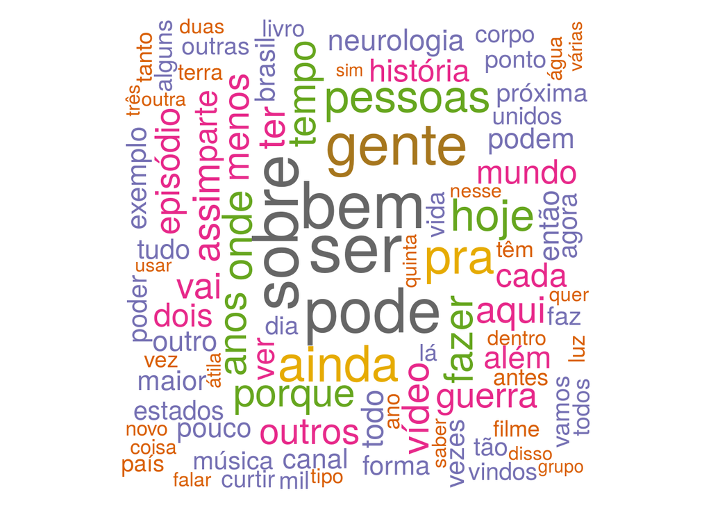

```r
wordcloud(df_total$word, df_total$freq, min.freq = 10, max.words=150, random.order=FALSE, rot.per=0.35,
          colors=brewer.pal(8, "Dark2"))
```

O gráfico do dashboard deve ser similar a este, porém, responsivo.

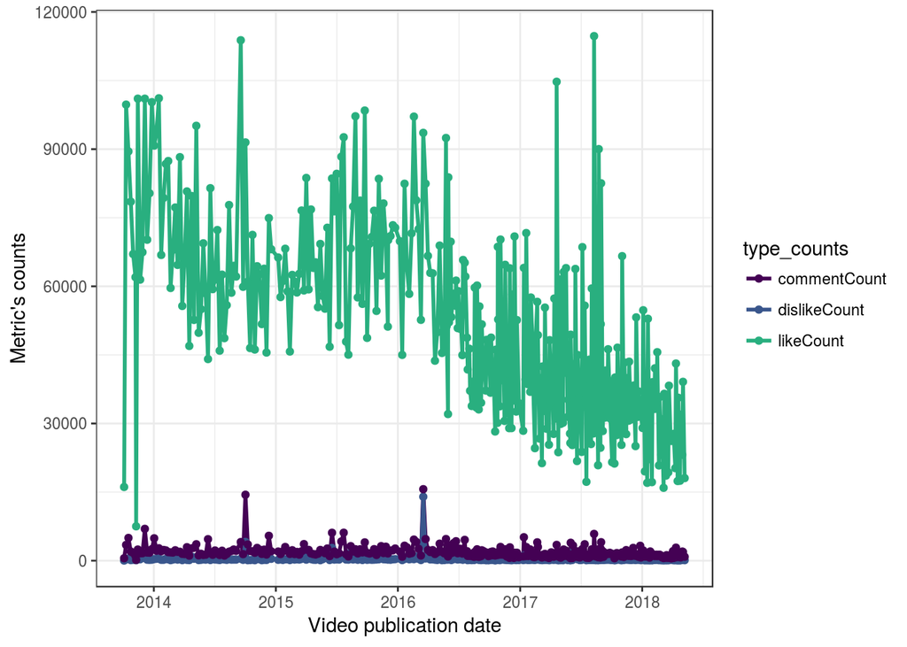

```r
all_vid_nerdologia %>%
    gather(key= type_counts, value= counts,
           c(likeCount, dislikeCount, commentCount, viewCount))  %>%
    filter(str_detect('likeCount|dislikeCount|commentCount', type_counts)) %>%
    ggplot(aes(x= publication_date, y= as.numeric(counts), col= type_counts)) +
    geom_line(size=1) +
    geom_point() +
    scale_x_date() +
    theme_bw() +
    ylab("Metric's counts") +
    xlab("Video publication date") +
    scale_color_manual(values = c('#440154FF', '#39568CFF', '#29AF7FFF'))
```